# Coursera Practical Machine Learning Class assignment

JLynch

December 14, 2017

## Executive summary:

Data collected from multiple accelerometers was used to predict the manner in which 6 individuals performed an exercise. More specifically, the individuals were asked to perform barbell lifts in 5 different ways. Data was recorded from accelerometers placed on the belt, forearm, arm and dumbell.The goal of this project was to use the recorded accelerometer data to predict the manner in which the barbell lift was performed. To this end, training and test datasets were downloaded respectively: https://d396qusza40orc.cloudfront.net/predmachlearn/pml-training.csv, https://d396qusza40orc.cloudfront.net/predmachlearn/pml-testing.csv. Variables that did not contain meaningful information were eliminated and it was determined that no transformations would be performed. A Random Forests model was then used to identify the 8 most important predictors. The Random Forests model was then recreated with only the 8 most important variables and subsequently used to predict the movement class in the test dataset. 20/20 predictions were made correctly.

## Detailed workflow

### 1. Load required libraries, load train datasets and examine dataset.

```
## [1] "Get dimensions of training and tesing datasets"
```

```
## [1] 19622   160
```

```
## [1]  20 160
```

- Determine percentage of rows that contain complete data

```
## [1] 2.069106
```

- Exclude columns that contain data in < 5% of the rows, update dimensions

```
## [1] "Examine training dimensions again"
```

```
## [1] 19622    60
```

- Examine column names and eliminate variables likely to be uninformative

```
##  [1] "X"                    "user_name"            "raw_timestamp_part_1"
##  [4] "raw_timestamp_part_2" "cvtd_timestamp"       "new_window"
##  [7] "num_window"           "roll_belt"            "pitch_belt"
## [10] "yaw_belt"             "total_accel_belt"     "gyros_belt_x"
## [13] "gyros_belt_y"         "gyros_belt_z"         "accel_belt_x"
## [16] "accel_belt_y"         "accel_belt_z"         "magnet_belt_x"
## [19] "magnet_belt_y"        "magnet_belt_z"        "roll_arm"
## [22] "pitch_arm"            "yaw_arm"              "total_accel_arm"
## [25] "gyros_arm_x"          "gyros_arm_y"          "gyros_arm_z"
## [28] "accel_arm_x"          "accel_arm_y"          "accel_arm_z"
## [31] "magnet_arm_x"         "magnet_arm_y"         "magnet_arm_z"
## [34] "roll_dumbbell"        "pitch_dumbbell"       "yaw_dumbbell"
## [37] "total_accel_dumbbell" "gyros_dumbbell_x"     "gyros_dumbbell_y"
## [40] "gyros_dumbbell_z"     "accel_dumbbell_x"     "accel_dumbbell_y"
## [43] "accel_dumbbell_z"     "magnet_dumbbell_x"    "magnet_dumbbell_y"
## [46] "magnet_dumbbell_z"    "roll_forearm"         "pitch_forearm"
## [49] "yaw_forearm"          "total_accel_forearm"  "gyros_forearm_x"
## [52] "gyros_forearm_y"      "gyros_forearm_z"      "accel_forearm_x"
## [55] "accel_forearm_y"      "accel_forearm_z"      "magnet_forearm_x"
## [58] "magnet_forearm_y"     "magnet_forearm_z"     "classe"
```

- We can remove the first column with row numbers and also remove user names. Additionally, our testing dataset contains 20 rows. We can therefore conclude that the data being presented are snapshots in time rather than a time series. Time related variables can therefore be excluded
- Examine ‘Window’ variables

```
##    no   yes
## 19216   406
```

```
##    Min. 1st Qu.  Median    Mean 3rd Qu.    Max.
##     1.0   222.0   424.0   430.6   644.0   864.0
```

```
##  [1] 11 11 11 12 12 12 12 12 12 12 12 12 12 12 12 12 12 12 12 12
```

- It does not appear that the ‘window’ related variables are meaningful so let’s eliminate them

### 2. Examine remaining variables, determine if data transformation is possible. Generate minimum value for every column.

```
##            roll_belt           pitch_belt             yaw_belt
##             "-10.20"             "-27.00"            "-167.00"
##     total_accel_belt         gyros_belt_x         gyros_belt_y
##                 " 0"              "-0.02"              "-0.02"
##         gyros_belt_z         accel_belt_x         accel_belt_y
##              "-0.02"               "-120"                "-10"
##         accel_belt_z        magnet_belt_x        magnet_belt_y
##               "-122"                "-10"                "354"
##        magnet_belt_z             roll_arm            pitch_arm
##               "-115"            "-100.00"             "-10.00"
##              yaw_arm      total_accel_arm          gyros_arm_x
##            "-100.00"                 " 1"              "-0.02"
##          gyros_arm_y          gyros_arm_z          accel_arm_x
##              "-0.02"              "-0.02"               "-100"
##          accel_arm_y          accel_arm_z         magnet_arm_x
##               "-100"               "-100"               "-100"
##         magnet_arm_y         magnet_arm_z        roll_dumbbell
##               "-100"               "-100"       "-100.0101819"
##       pitch_dumbbell         yaw_dumbbell total_accel_dumbbell
##       "-100.1023024"       "-100.0043898"                 " 0"
##     gyros_dumbbell_x     gyros_dumbbell_y     gyros_dumbbell_z
##            "-204.00"              "-0.02"             " -0.02"
##     accel_dumbbell_x     accel_dumbbell_y     accel_dumbbell_z
##               "-100"               "-100"               "-100"
##    magnet_dumbbell_x    magnet_dumbbell_y    magnet_dumbbell_z
##               "-100"              "-3600"             "-100.0"
##         roll_forearm        pitch_forearm          yaw_forearm
##            "-100.00"             "-10.00"            "-100.00"
##  total_accel_forearm      gyros_forearm_x      gyros_forearm_y
##                "  0"             "-22.00"             " -0.02"
##      gyros_forearm_z      accel_forearm_x      accel_forearm_y
##             " -0.02"               "-100"               "-100"
##      accel_forearm_z     magnet_forearm_x     magnet_forearm_y
##               "-100"              "-1010"           "-100.000"
##     magnet_forearm_z               classe
##          "-100.0000"                  "A"
```

- We still have 52 variables (excluding class) and many of them have negative values which we can’t log transform. Because we don’t know what variables might be important, let’s try a Random Forest model as it is designed to handle this type of data. It also does not require an additional cross-validation step.

### 3. Build Random Forest model, characterize and evaluate out of sample error

```
##
## Call:
##  randomForest(formula = classe ~ ., data = training)
##                Type of random forest: classification
##                      Number of trees: 500
## No. of variables tried at each split: 7
##
##         OOB estimate of  error rate: 0.29%
## Confusion matrix:
##      A    B    C    D    E  class.error
## A 5578    1    0    0    1 0.0003584229
## B   10 3784    3    0    0 0.0034237556
## C    0   12 3408    2    0 0.0040911748
## D    0    0   19 3195    2 0.0065298507
## E    0    0    0    6 3601 0.0016634322
```

- This looks pretty good. Out of sample error rate is generated during model creation and reported as OOB estimate (https://www.stat.berkeley.edu/~breiman/RandomForests/cc_home.htm#ooberr). Our out of sample error rate is estimated to be 0.29. We will refine our model by plotting and identifying the most important predictors.

### 4. Rank and plot variables by importance.

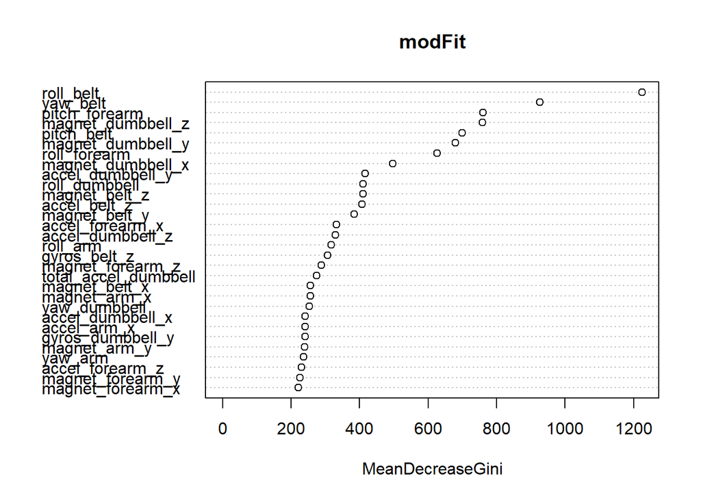

```
##                  nms       val
## 1          roll_belt 1224.1378
## 3           yaw_belt  925.8435
## 41     pitch_forearm  759.6667
## 39 magnet_dumbbell_z  759.5656
## 2         pitch_belt  699.9589
## 38 magnet_dumbbell_y  679.7157
## 40      roll_forearm  626.7037
## 37 magnet_dumbbell_x  497.6219
## 35  accel_dumbbell_y  415.7876
## 27     roll_dumbbell  410.8094
## 13     magnet_belt_z  410.2001
## 10      accel_belt_z  406.8640
```

- 8 of these predictors seem to be grouped together so we will only include those in the model. We can now recreate our prediction model with only 8 predictors.

### 5. Recreate Random Forest model and evaluate

```
##
## Call:
##  randomForest(formula = classe ~ ., data = training_filt)
##                Type of random forest: classification
##                      Number of trees: 500
## No. of variables tried at each split: 2
##
##         OOB estimate of  error rate: 1.01%
## Confusion matrix:
##      A    B    C    D    E class.error
## A 5546   14   16    4    0 0.006093190
## B   20 3718   45   14    0 0.020805899
## C    2   21 3381   18    0 0.011981297
## D    0    3   12 3198    3 0.005597015
## E    0   14    8    5 3580 0.007485445
```

- The out of sample error rate is now 1.01% but we will use it in the interest of simplifying the model.

### 6. Filter test dataset per the same criteria used for training. Predict movement class for test dataset.

```
## [1] 20 60
```

```
##  1  2  3  4  5  6  7  8  9 10 11 12 13 14 15 16 17 18 19 20
##  B  A  B  A  A  E  D  B  A  A  B  C  B  A  E  E  A  B  B  B
## Levels: A B C D E
```